# Untitled

Josué David Mendoza Hewitt

2024-09-12

```r
library(psych)
library(readxl)
library(ellipse)
```

```r
library(corrplot)
library(Hmisc)
library(ggplot2)
library(ggplot2)
library(readxl)
library(corrplot)
library(knitr)
library(gridExtra)
library(ggplot2)
library(gridExtra)
library(grid)
library(patchwork)
library(kableExtra)

datos_env <- read.delim("https://raw.githubusercontent.com/JosmenX10/Informe-final-de-multivariada/main/Base%20de%20datos%20y%20contextos/vltava_env.csv", sep = ",")
 #Llamamos a la base de datos.

datos_env <- read.delim("https://raw.githubusercontent.com/JosmenX10/Informe-final-de-multivariada/main/Base%20de%20datos%20y%20contextos/vltava_env.csv", sep = ",")

#Seleccionamos entre grupos de variables
topo <- datos_env[,4:17]#Seleccionamos solamente las variables topograficas y de suelo.

ellin <- datos_env[,19:24]#seleccionamos solo las variables indices-ellinger.
#-----------------------------------------------------------------------

#Generamos las matrices de correlación para analisis
topocor <- cor(topo, method = "spearman") #correlación entre topograficas.

pval_topo <- corr.test(topo, adjust="none",method = "spearman")$p #p-value de correlaciones entre topograficas.
ellin_topocor <- cor(y = topo, x = ellin, method = "spearman") #correlación entre topograficas.

pval_ellin<- corr.test(y= topo, x= ellin, adjust="none",method = "spearman")$p #p-value de correlaciones entre topograficas.
```

# Evaluación de la relación entre variables topograficas y topologica

A partir de correlogramas se puede tener una vista general de la relaciones entre las variables, visualizando el grado de correlación y el nivel de significancia de estas relaciones. Por ejemplo, la @fig-fig1 refleja la estrecha relación positiva entre las variables de orientación sureste y la orientación sur-sureste al tener un 83% de correlación entre sus datos con el mayor nivel de significancia(p-value<0.001), así mismo pasaría con los indices de capacidad calorifica que se derivan de estos, los cuales tienen una correlación positiva entre si, en la que las variaciones de uno se explicarian por las variaciones del otro en el 79% de los datos, esto se entiende ya que el cambio en la orientación sureste entre las parcelas también deberia ser acompoñada por cambios en la orientación sur-sureste. El tipo de relieve a favor de la pendiente tiende a ser más convexa a medida que aumenta la altitud, esto se evidencia por un grado de correlación del 62% . Entre los tipos de suelo, el fluvisol tiene una correlación considerablemente negativa con la altitud y las superficies en dirección a la pendiente (-0.62 y -0.67), teniendo el mayor nivel de significancia. A continuación se realizará una exploración visual de las relaciones con el mayor nivel de significancia y con un grado de correlación mayor al 60%.

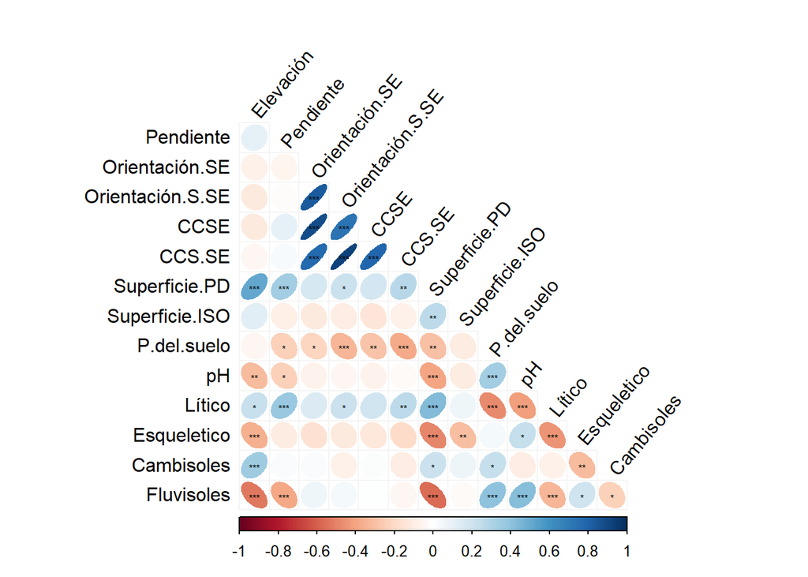

```r
#| label: fig-fig1
#| fig-cap: Correlograma de las relaciones de las variables topologicas y topograficas usando el indice de correlación de Spearman: Los elipses azules inclinadas a la derecha representan las relaciones lineales positivas, mientras que las elipses rojas inclinadas a la izquierda representan las relaciones lineales negativas. El nivel de significancia se representa por medio de asteriscos(* = 0.05, ** = 0.01, 0.001 = ***).



corrplot(topocor,method = "ellipse",type ="lower",diag = FALSE,
         tl.pos = "ld",order ="original",tl.col = "black",addCoef.col= NULL, cl.pos = T, sig.level = c(0.001,0.01,0.05),
         p.mat = pval_topo,insig = c("label_sig"), pch= "*",pch.cex = 0.5, pch.col ="black",
         tl.cex = 1.0, number.cex = 0.9, cl.cex = 0.8,tl.srt = 50,addgrid.col = "#f5f5f5")
```

En la @fig-fig2-A se confirma la relación lineal postiva entre la orientación sureste y la orientación sur-sureste, tener estas dos variables en cuenta para los analisis podría generar ruido y disminuir la posibilidad de una correcta interpretación. Cabe resaltar que al medir los valores de orientación medido en una magnitud escalar, aumentando el valor de manera positiva a medida que la orientación de las parcelas se acercan a la orientación sureste puede generar que dos parcelas con dos direcciones diferentes tengan el mismo valor al situarse a la misma cantidad de grados desviados del noroeste, pero en la orientación sur-sureste estas tendran valores diferentes @fig-fig3, razon por la que en el grafico se observa que cada valor en el eje x tendría dos valores en eje y, generando dos lineas de puntos en las partes de arriba y abajo de la linea de tendencia. La @fig-fig2 evidencia una estrecha relación entre las vairables de carga calorifica en valores cercanos a 0, pero a medida que aumenta la carga calorifica del sureste parece haber valores más desviados de la linea suavizada de tendencia. Los datos que muestran cierta diferencia a los patrones generales podrían ser debido a mediciones erradas de las orientaciones o situaciones particulares de ciertas parcelas.

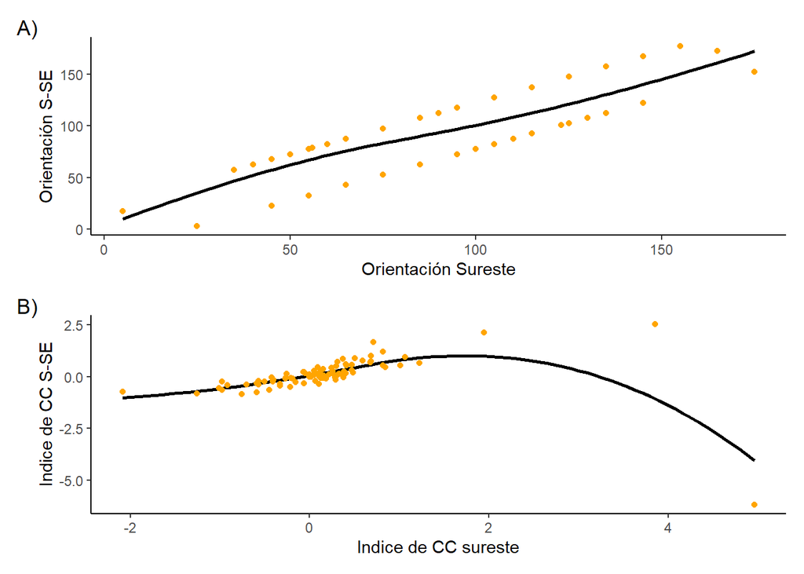

```r
g1 = ggplot(datos_env, aes(x = Orientación.SE , y = Orientación.S.SE)) +
  geom_smooth(aes(x = Orientación.SE, y = Orientación.S.SE), se = F, span = 1, col = "black") +
  geom_point(col = "orange") + labs(x = "Orientación Sureste",y= "Orientación S-SE" , tag = "A)") +
  theme_classic()


g2 = ggplot(datos_env, aes(x = CCSE , y = CCS.SE)) +
  geom_smooth(aes(x = CCSE, y = CCS.SE), se = F, span = 1, col = "black") +
  geom_point(col = "orange") + labs(x = "Indice de CC sureste", y = "Indice de CC S-SE", tag = "B)") +
  theme_classic()


g1/g2
```

```r
include_graphics("C:\\Users\\Asus\\Desktop\\Analisis multivariado\\Informe-final-de-multivariada\\Graficos\\Explicaciones\\Orientación.svg")
```

[figure not shown]

Diagrama explicativo de las mediciones de orientación.

A partir de la @fig-fig4 se evidencia un claro patron de los tipos de superficie o relieve a favor de la pendiente a medida que aumenta la altitud, siendo posible observar más parcelas con relieve concavo en altitudes bajas que en altitudes altas, así mismo los relieves neutros son más comunes en altitudes intermedias y los relieves convexos más comunes en altitudes mayores, aunque las muescas dan la posibilidad de que no hubiera diferencias significativas entre estas dos ultimas categorias de relieve.

```
## Notch went outside hinges
## ℹ Do you want `notch = FALSE`?
```

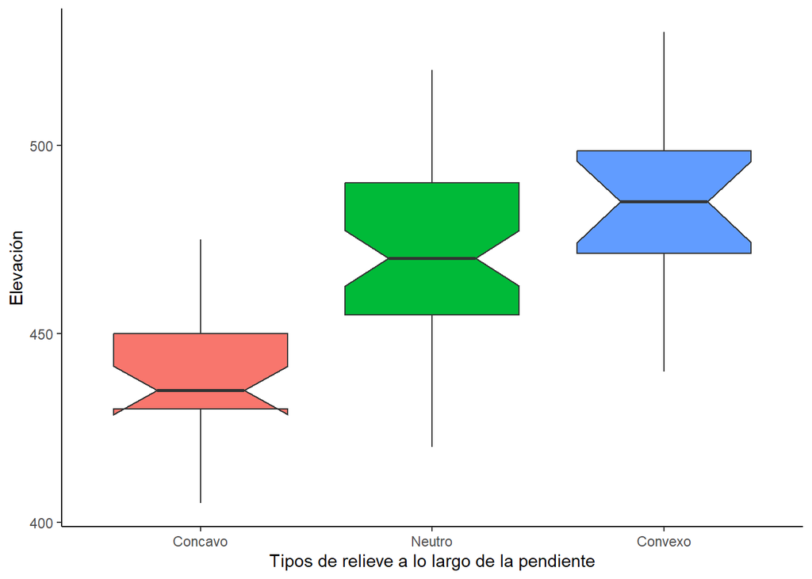

Diagrama de cajas y bigotes para comparar las altitudes entre distintos tipos de superficie en las parcelas según el eje a favor de la pendiente.

```r
g3 = ggplot(datos_env,aes(x=factor(Superficie.PD),y=Elevación)) +
  geom_boxplot(aes(y= Elevación, fill = factor(Superficie.PD)), notch = TRUE) + theme_classic() +
  guides(fill = "none") +   scale_x_discrete(labels = c("1" = "Convexo", "0" = "Neutro", "-1" = "Concavo")) +
  labs( x = "Tipos de relieve a lo largo de la pendiente")

g3
```

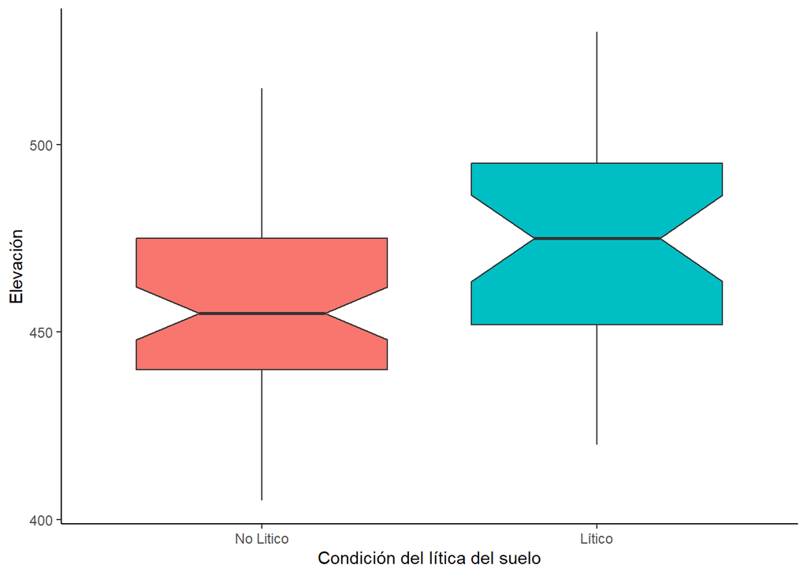

Diagrama de cajas y bigotes para comparar las altitudes para las parcelas en suelos líticos y no líticos.

```r
g4 = ggplot(datos_env,aes(x=factor(Lítico),y=Elevación)) +
  geom_boxplot(aes(y= Elevación, fill = factor(Lítico)), notch = TRUE) + theme_classic() +
  guides(fill = "none") +   scale_x_discrete(labels = c("1" = "Lítico", "0" = "No Litico")) + labs(x = "Condición del lítica del suelo")

g4
```

La condición de suelo litica es también dependiente del tipo de relieve, siendo que en las parcelas de relieve convexo son más frecuentes que los suelos no liticos, y en las parcelas con relieve neutro ya los suelos líticos son menos frecuente, y en los relieves concavos las parcelas con suelos no líticos son mucho más frecuentes que los líticos. Por lo tanto, los relieves convexos pueden favorecer el asentamiento de suelos líticos antes que de suelos no líticos, mientras que en los concavos pasa lo contrario.

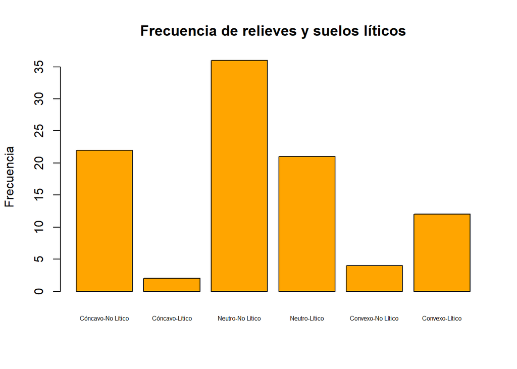

histograma para comparar las frecuencias de las parcelas con distintos tipos de superficie según el eje a favor de la pendiente y si presenta o no el tipo de suelo lítico.

```r
Sup.pd <- factor(datos_env$Superficie.PD, levels = c(1, 0, -1), labels = c("Convexo", "Neutro", "Cóncavo"))

Pendiente.pd <- factor(datos_env$Lítico, levels = c(1, 0), labels = c("Lítico", "No Lítico"))

factores <- paste(Sup.pd,Pendiente.pd, sep ="-")

je <- c("Cóncavo-No Lítico", "Cóncavo-Lítico","Neutro-No Lítico","Neutro-Lítico","Convexo-No Lítico" , "Convexo-Lítico")

datos_env$factores <- factor(factores, levels = je)

frecuencia_factores <- as.data.frame(table(datos_env$factores))

frecuencia <- frecuencia_factores$Freq

barplot(frecuencia,
        main = "Frecuencia de relieves y suelos líticos",
        ylab = "Frecuencia",
        col = "orange",
        border = "black", cex.names = 0.5,width = 2.5, names.arg = je)
```

# **Evaluación de la relación de las variables topograficas y topologicas con variables ambientales(indices de Hellinberg)**

En el correlograma presentado en la @fig-fig7 observamos los grados de correlación entre las variables topograficas y topologicas con las variables ambientales medidas de manera indirecta con el promedio de indices de hellinberg en cada parcela, entonces habrían seis indices, una por cada variable y ambas se representan numericamente en las mismas escalas. De las seis variables cinco se relacionan de manera significativa con las variables de orientación y carga calorifica de las cuales la luz, la temperatura y la continentalidad se relacionan positivamente, mientras que la humedad y los nutrientes se relacionan negativamente, estas relaciones se ven más detalladas en los diagramas de dispersión de la @fig-fig8(A-D). Por lo tanto la orientación y la capacidad calorifica de la parcela puede ser determinantes para la variación en las condiciones de habitats entre las parcelas.

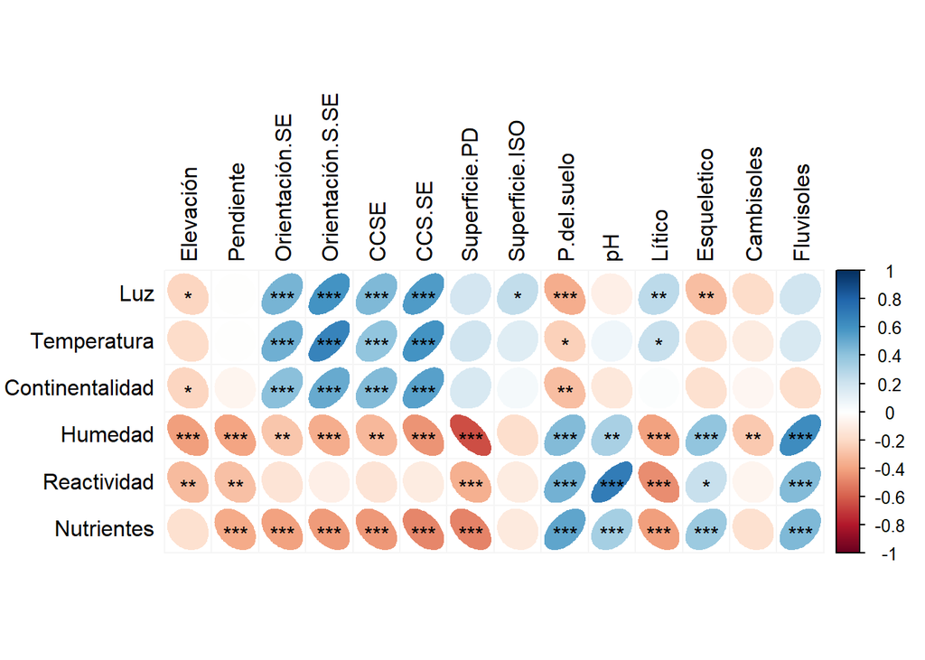

Correlograma de las relaciones de las variables topologicas y topograficas con los indices de Hellinberg usando el indice de correlación de Spearman: Los elipses azules inclinadas a la derecha representan las relaciones lineales positivas, mientras que las elipses rojas inclinadas a la izquierda representan las relaciones lineales negativas. El nivel de significancia se representa por medio de asteriscos(* = 0.05, ** = 0.01, 0.001 = ***).

```r
corrplot(ellin_topocor,method = "ellipse",
         tl.pos = "dt",tl.col = "black",sig.level = c(0.001,0.01,0.05),
         p.mat = pval_ellin, insig = c("label_sig"), pch= "*",pch.cex = 1.0, pch.col ="black"
         ,tl.cex = 1.0, number.cex = 0.9,addgrid.col = "#f5f5f5")
```

Entonces si toma a los indices de hellinberg como medidas indirectas de las condiciones de habitat, podriamos determinar dos grupos de variables, de las cuales uno se conforma por la luz ,temperatura y continentalidad mientras el otro se conforma por la humedad, reactividad y nutrientes, de modo que si un grupo se relaciona positivamente con una de las variables topologicas y topograficas positiva o negativamente, el otro podría relacionarse de manera contraria o no relacionarse. Caso en los que una variable se relaciona con uno de estos dos grupos pero no con el otro estaría el pH y la inclinación de la pendiente, en el que la inclinación de la pendiente se relaciona negativamente con la humedad, reactividad y nutrientes, pero mostraría ningún tipo de correlación con la luz, temperatura y continentalidad. Por otro lado, el pH diluido de muestras de suelo también se relacionan significativamente con el mismo grupo de variables pero de manera positiva, y tampoco tienen un grado de correlación considerable con la luz, temperatura y continentalidad.

```r
include_graphics("C:\\Users\\Asus\\Desktop\\Analisis multivariado\\Informe-final-de-multivariada\\Graficos\\Excel\\Ellenberg vs ambientales.svg")
```

[figure not shown]

Diagrama de dispersión de las variables topograficas y topolagicas contra los indices de Hellinberg.A) Relación entre continentalidad, temperatura y luz con la orientación sur-sureste. B) Relación entre humedad, reactividad y nutrientes con la orientación sur-sureste, C)Relación entre continentalidad, temperatura y luz con la capacidad calorifica sur-sureste. D)Relación entre humedad, reactividad y nutrientes con la capacidad calorifica sur-sureste, E)Relación entre humedad, reactividad y nutrientes con el pH diluido de las muestras de suelo.F)Relación entre humedad, reactividad y nutrientes con la pendiente de la parcela.

```r
include_graphics("C:\\Users\\Asus\\Desktop\\Analisis multivariado\\Informe-final-de-multivariada\\Graficos\\Excel\\Boxplot_ Ellenberg vs ambientales.svg")
```

[figure not shown]

Diagrama de cajas y bigotes para comparar los indices de Hellinberg en distintas condiciones topograficas.A)Comparación del indice de humedad entre distintos tipos de superficie.B)Comparación del indice de nutrientes entre distintos tipos de superficie.C)Comparación del indice de humedad entre suelos líticos y no líticos.